# Intoduction to R

LISA + CRDDS

September 11, 2019

[figure not shown]

# Agenda

1. Resources
2. Preliminaries
3. Base Functions
4. Tidy Data
5. Data Wrangling
6. Data Visualization
7. Test Your Skills
8. How to Research R

# Resources

#### R for Data Science - Book

- http://r4ds.had.co.nz

#### Base R cheat sheet

- https://www.rstudio.com/wp-content/uploads/2016/05/base-r.pdf

#### R markdown cheat sheet

- https://www.rstudio.com/wp-content/uploads/2015/02/rmarkdown-cheatsheet.pdf

#### dyplyr cheat sheet - data wrangling

- https://www.rstudio.com/wp-content/uploads/2015/02/data-wrangling-cheatsheet.pdf

#### ggplot cheat sheet - data visualization

- https://www.rstudio.com/wp-content/uploads/2015/03/ggplot2-cheatsheet.pdf

# Preliminaries

#### 1. R Studio Interface

- Console
- Environment
- File Window
- Viewer Window
- History
- Plots
- Help
- Packages

#### 2. Creating Scripts

Create a script to keep track of your analysis. Save the script where you want it.

#### 3. Working Directory

Set the working directory. This tells R where to look for files. Click Session - Set Working Directory - To source file location. Any data files that you want to analyze should be placed here. Also any data files that you save will be saed here.

```r
getwd()
```

```
## [1] "/Users/nickvarberg/Desktop/Work/R Shortcourses 2019"
```

```r
#setwd("C:/Users/nickvarberg/Desktop/Work/R Shortcourses 2019")
```

#### 4. Packages

Packages that we will need for today.

- **tidyverse**: “The tidyverse is an opinionated collection of R packages designed for data science. All packages share an underlying design philosophy, grammar, and data structures.” - Taken directly from their website
- **fivethirtyeight**: A collection of interesting datasets to analyze.

All of you should have come ready with the tidyverse installed. Many of you will likely not have the the fivethirtyeight package downloaded. How can we install this package to our computer?

## Exercise 1:

Install the fivethirtyeight package.

```r
library(tidyverse)
library(fivethirtyeight)
```

#### 5. Import Dataset

Now it’s time to load the dataset. Note that we will be using a built-in dataset from the fivethirtyeight package that contains information on US Births from 1994 to 2003. If you are importing your own dataset, we address this later in the workshop. Please see the script “r_zero.r” on our OSF site for more information on this. (or just google it). Here is how we load the data from the fivethirtyeight package.

```r
data <- US_births_1994_2003
```

# Base Functions

Here we list some functions that come in the base pacage of R. We can use these functions to get some basic information on our dataset.

#### 1. Dimensions

Compute the dimensions of the data frame.

```r
dim(data)
```

```
## [1] 3652    6
```

#### 2. Number of Rows

Compute the number of rows of the data frame.

```r
nrow(data)
```

```
## [1] 3652
```

#### 3. Number of Columns

Compute the number of columns of the data frame.

```r
ncol(data)
```

```
## [1] 6
```

#### 4. Column names

Display the column names of the data frame.

```r
colnames(data)
```

```
## [1] "year"          "month"         "date_of_month" "date"
## [5] "day_of_week"   "births"
```

#### 5. Head of the data

Display the first few rows of the data frame.

```r
head(data)
```

```
## # A tibble: 6 x 6
##    year month date_of_month date       day_of_week births
##   <int> <int>         <int> <date>     <ord>        <int>
## 1  1994     1             1 1994-01-01 Sat           8096
## 2  1994     1             2 1994-01-02 Sun           7772
## 3  1994     1             3 1994-01-03 Mon          10142
## 4  1994     1             4 1994-01-04 Tues         11248
## 5  1994     1             5 1994-01-05 Wed          11053
## 6  1994     1             6 1994-01-06 Thurs        11406
```

## Tidy Data

Our goal is to have our data “Tidy”. Tidy data has two key features. (1) Each row represents a case (ie. observational unit of the sample). (2) Each column represents a variable (ie. an attribute of the cases). Here cases are individual days and variables include month, year, and births. We can always tidy up our data if it comes to us in a non-tidy format using data wrangling techniques which will be addressed in a bit.

#### 6. Structure of the data

Display the data structures for each column.

```r
str(data)
```

```
## Classes 'tbl_df', 'tbl' and 'data.frame':    3652 obs. of  6 variables:
##  $ year         : int  1994 1994 1994 1994 1994 1994 1994 1994 1994 1994 ...
##  $ month        : int  1 1 1 1 1 1 1 1 1 1 ...
##  $ date_of_month: int  1 2 3 4 5 6 7 8 9 10 ...
##  $ date         : Date, format: "1994-01-01" "1994-01-02" ...
##  $ day_of_week  : Ord.factor w/ 7 levels "Sun"<"Mon"<"Tues"<..: 7 1 2 3 4 5 6 7 1 2 ...
##  $ births       : int  8096 7772 10142 11248 11053 11406 11251 8653 7910 10498 ...
```

## Data Structures

A list of common data types.

- int - integer
- numeric - number
- factor - group
- logical - True/False
- Date - date

Note: Sometimes when your data is loaded, R will recognize a column with an incorrect structure. For example, column b is a string but we want it to be numeric. We change it using as.numeric().

```r
b <- c("2.0", "3.5", "56.0")
str(b)
```

```
##  chr [1:3] "2.0" "3.5" "56.0"
```

```r
b <- as.numeric(b)
str(b)
```

```
##  num [1:3] 2 3.5 56
```

#### 7. Column Access

Access a column by its name.

```r
births <- data$births
births
```

```
##  [1]  8096  7772 10142 11248 11053 11406 11251  8653  7910 10498 11706
## [12] 11567 11212 11570  8660  8123 10567 11541 11257 11682
##  [ reached getOption("max.print") -- omitted 3632 entries ]
```

## Exercise 2:

Extract the day of the week column into a vector. Try to convert the column into a numeric vector and see what happens.

#### 8. Unique elements of a column

Get the unique elements of a column in a data frame.

```r
# Get the unique years of the data
years <- unique(data$year)
years
```

```
##  [1] 1994 1995 1996 1997 1998 1999 2000 2001 2002 2003
```

#### 9. Maximum of a column

Find the maximum element of a vector.

```r
maxbirths <- max(births)
maxbirths
```

```
## [1] 14540
```

#### 10. Index of maximum

Find the index where a maximum occurrs.

```r
# Find the date of the maximum births
maxindex <- which.max(births)
maxdate <- data$date[maxindex]
maxdate
```

```
## [1] "1999-09-09"
```

## Exercise 3:

Find the day where the least number of births occurred for our dataset and also find the least number of births.

#### 11. Mean

Compute the mean of a vector.

```r
# Compute the average number of births in a given day
mean(births)
```

```
## [1] 10876.82
```

#### 11. Standard Deviation

Compute the standard deviation of a vector.

```r
# Compute the standard deviation of the number of births in a given day
sd(births)
```

```
## [1] 1858.567
```

# Data Wrangling

There are many useful functions for altering your data frame.

#### 1. View Dataset

View the data frame in a new window.

```r
# Display data frame
View(data)
```

#### 2. Order Data Frame

```r
# Order by number of births
data <- data %>% arrange(desc(births))
head(data)
```

```
## # A tibble: 6 x 6
##    year month date_of_month date       day_of_week births
##   <int> <int>         <int> <date>     <ord>        <int>
## 1  1999     9             9 1999-09-09 Thurs        14540
## 2  2003    12            30 2003-12-30 Tues         14438
## 3  2003     9            16 2003-09-16 Tues         14145
## 4  2003     9             3 2003-09-03 Wed          14119
## 5  2003     9            23 2003-09-23 Tues         14036
## 6  2002     9            12 2002-09-12 Thurs        13982
```

```r
data <- data %>% arrange(year)
head(data)
```

```
## # A tibble: 6 x 6
##    year month date_of_month date       day_of_week births
##   <int> <int>         <int> <date>     <ord>        <int>
## 1  1994     7             6 1994-07-06 Wed          13086
## 2  1994     7             7 1994-07-07 Thurs        13049
## 3  1994     9            16 1994-09-16 Fri          12884
## 4  1994    12            20 1994-12-20 Tues         12880
## 5  1994     9             9 1994-09-09 Fri          12811
## 6  1994    11            22 1994-11-22 Tues         12764
```

#### 3. Rename Columns

Rename specific columns of your data.

```r
# Rename dat_of_month and day_of_week columns
data <- data %>% rename(day = date_of_month, weekday = day_of_week)
```

#### 4. Filter Rows

Select rows of a data frame based on a certain condition.

```r
# Select days only in the month of July and do the same for Jan
july_data <- data %>% filter(month == 7)
jan_data <- data %>% filter(month == 1)
# Select days only in the month of january
jan_2000_data <- data %>% filter(month == 1 & year == 2000)
dim(jan_2000_data)
```

```
## [1] 31  6
```

## Exercise 4:

Filter out the data for the first half of the year (January through June).

#### 5. Select Columns

Select specific columns of a data frame.

```r
# Select days only the columns of date and births
selected_data <- data %>% select(date, births)
```

## Exercise 5:

Select the columns for year, day, and births out of july_data.

```r
# Select days only in the month of July
july_data <- july_data %>% select(year,day,births)
```

#### 6. Separate Columns

Separate one column into several.

```r
# Separate date of selected_data into 3 columns
parsed_data <- selected_data %>% separate(date, c('y','m','d'))
```

#### 7. Creating Columns

Add an additional column to the data frame.

```r
# Create a column that indicates if it is a summer month (June, July, August).
data <- data %>% mutate(summer = between(month,6,8))
str(data)
```

```
## Classes 'tbl_df', 'tbl' and 'data.frame':    3652 obs. of  7 variables:
##  $ year   : int  1994 1994 1994 1994 1994 1994 1994 1994 1994 1994 ...
##  $ month  : int  7 7 9 12 9 11 9 7 9 9 ...
##  $ day    : int  6 7 16 20 9 22 8 15 7 15 ...
##  $ date   : Date, format: "1994-07-06" "1994-07-07" ...
##  $ weekday: Ord.factor w/ 7 levels "Sun"<"Mon"<"Tues"<..: 4 5 6 3 6 3 5 6 4 5 ...
##  $ births : int  13086 13049 12884 12880 12811 12764 12693 12691 12660 12655 ...
##  $ summer : logi  TRUE TRUE FALSE FALSE FALSE FALSE ...
```

## Exercise 6:

Create a column keeping track of the cumulative total of births. Hint: use the summary function “cumsum(colname)”.

#### 8. Summarizing

Compute summary statistics of your data frame.

```r
# Compute the mean number of births for a given day
overall_mean <- data %>% summarise(average = mean(births))
```

#### 9. Grouping by variables

```r
# Compute the mean and median number of births by weekday
weekday_mean <- data %>%
  group_by(weekday) %>%
  summarise(average = mean(births))
```

## Exercise 7:

Compute the average number of births by year, along with the standard deviation.

#### 10. Binding Rows

Bind two dataframes together by row.

```r
# Bind data frames by row
janjul_data <- jan_data %>%
  bind_rows(july_data)
```

#### 11. Joining Data frames

Bind two dataframes together by similar columns.

```r
# Join two data frames together
joined_data <- jan_data %>%
  left_join(july_data, by = c("year","day"))
```

## Exercise 8:

Rename the new columns of joined_data.

#### 12. Gather columns into rows

Separate multiple columns into one.

```r
# Select days only in the month of July
gathered_data <- joined_data %>%
  gather(key = month, value = births, c("births.x","births.y"))
# key: column name representing new variable
# value: column name representing variable values
# remaining: columns to gather
```

#### 13. Saving Data Frames

Save the data frame to a .csv file.

```r
write.csv(gathered_data, "mydataframe.csv")
```

## Exercise 9:

Save one of your data frames in your environment to a csv.

#### 14. Loading Data Frames

Read a .csv file into R.

```r
loaded_data <- read.csv("mydataframe.csv")
```

# Basic Data Visualization

#### 1. Create a histogram for births

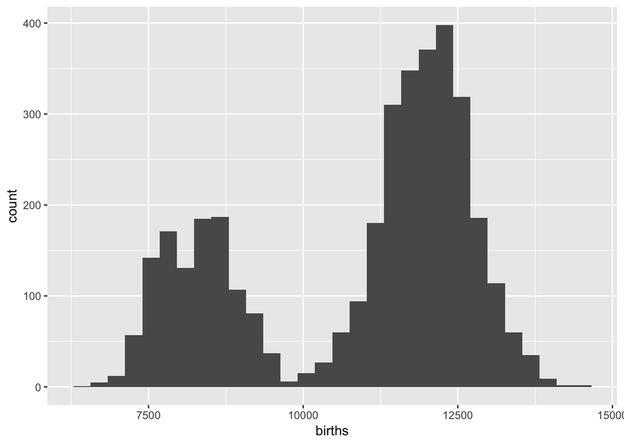

```r
# Histogram of births
ggplot(data = data, aes(x=births)) +
  geom_histogram(bins = 30)
```

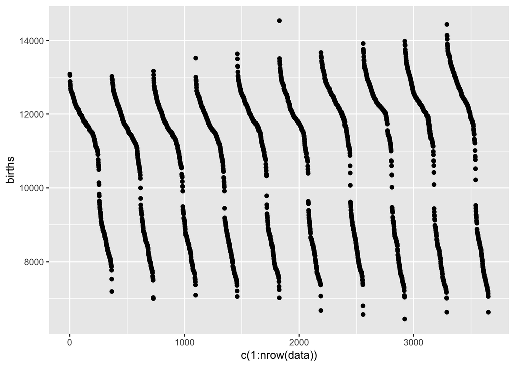

```r
# Scatter plot of births
ggplot(data = data, aes(x=c(1:nrow(data)), y = births)) +
  geom_point()
```

#### 3. Create a boxplot of births by month

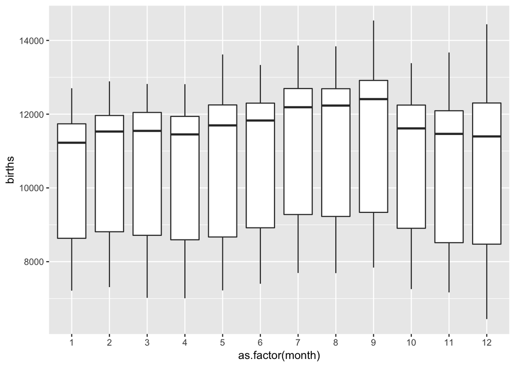

```r
# Boxplot of births by month
ggplot(data = data, aes(x=as.factor(month), y = births)) +
  geom_boxplot()
```

## Exercise 10:

Create more plots to figure out what is accounting for our birth differences in our scatter plot.

# Test Your Skills

- Find the month/year combo with the highest total number of births.
- Find the month/year combo with the least total number of births.
- Create new columns for the remaining seasons.
- Compute a histogram for the daily births on weekends.
- Compute the average number of births by season.
- Extract the births for valentines day. Create a dot-plot of the values. You may have to google how to do this one.

# How to research for R

**Google is your best friend**. There are a ton of resources and online tutorials out there to help you learn R.